# Coronavirus v Čechách

## Přehled

Základní přehled (testy)

| Datum | Přírustkový počet testů | Kumulativní počet testů | Pozitivita testů (v %) |
| --- | --- | --- | --- |
| 2020-11-18 | 24355 | 2856683 | 22.65 |
| 2020-11-19 | 26418 | 2883101 | 24.49 |
| 2020-11-20 | 25510 | 2908611 | 22.78 |
| 2020-11-21 | 14423 | 2923034 | 22.12 |
| 2020-11-22 | 6981 | 2930015 | 21.62 |

Základní přehled (nákaza)

| Datum | Přírustkový počet nakažených | Kumulativní počet nakažených | Kumulativní počet vyléčených | Kumulativní počet úmrtí |
| --- | --- | --- | --- | --- |
| 2020-11-18 | 5516 | 475283 | 396209 | 6850 |
| 2020-11-19 | 6470 | 481753 | 397171 | 6975 |
| 2020-11-20 | 5810 | 487563 | 398035 | 7077 |
| 2020-11-21 | 3191 | 490754 | 398300 | 7192 |
| 2020-11-22 | 1509 | 492263 | 398481 | 7291 |

Aktuálně hospitalizovaní: `5296`

Podíl nakažených s těžkým průběhem: `6.01`%

Smrtnost: `1.48`%

# SIR MODELY

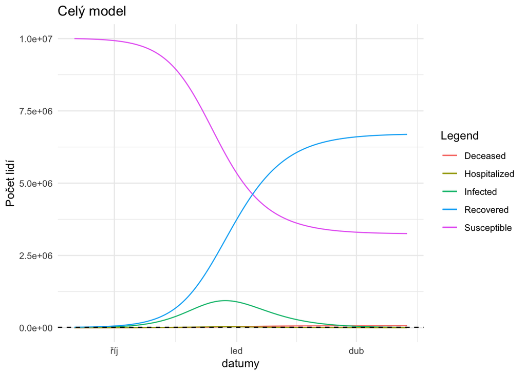

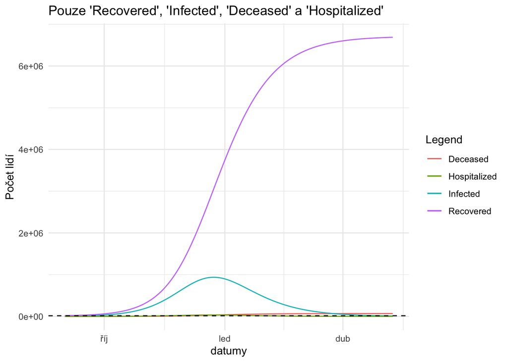

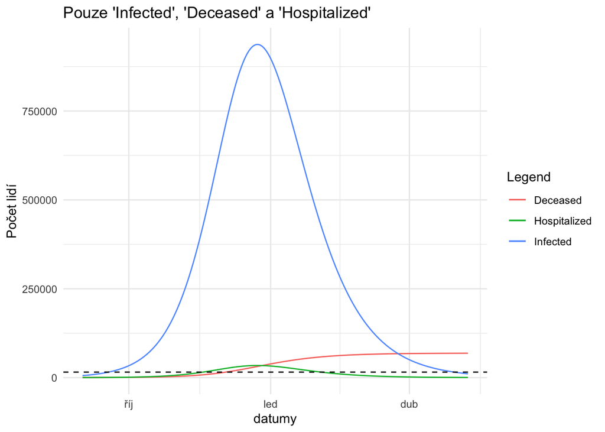

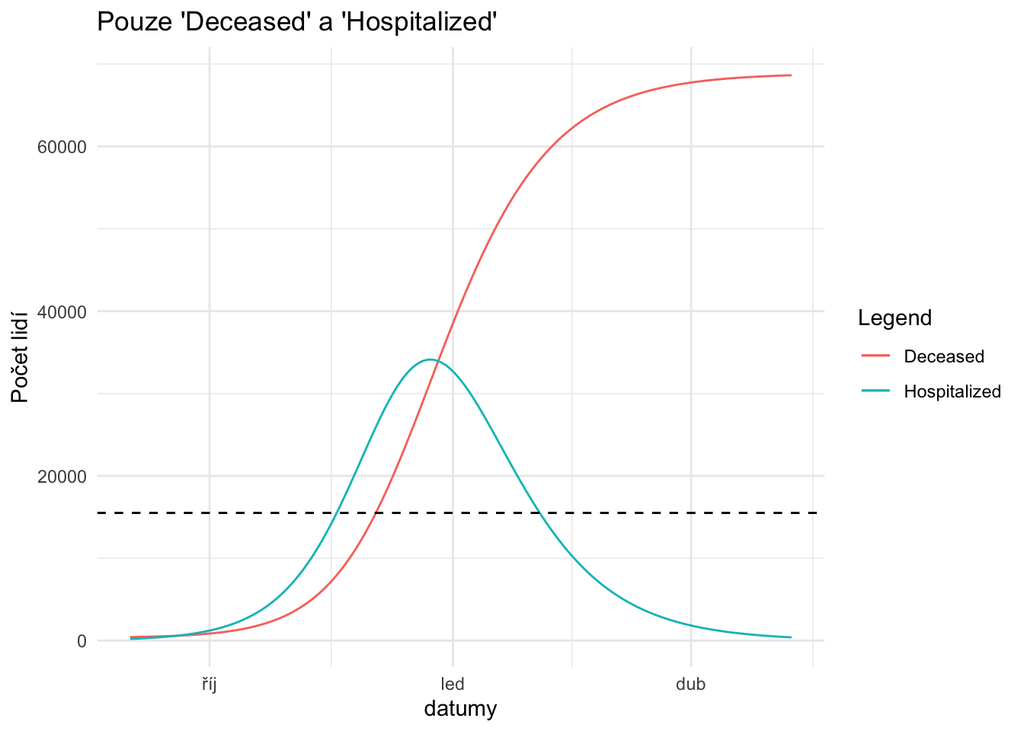

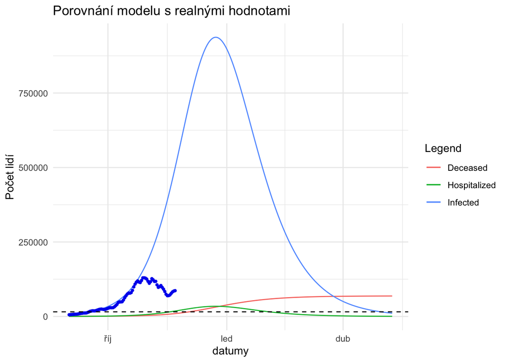

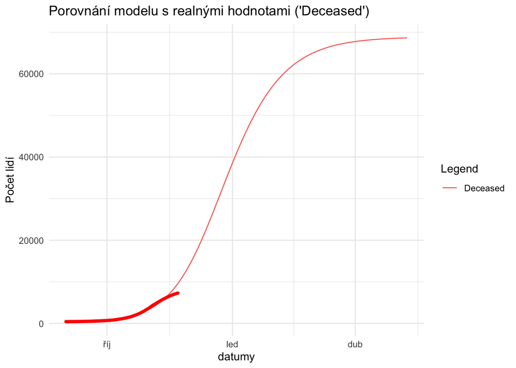

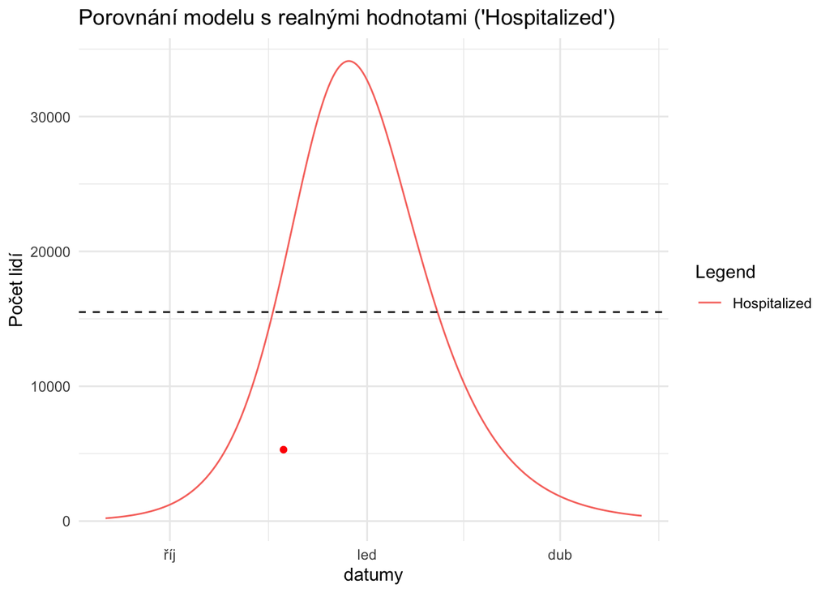

## Informace

`Peak nastane dne 2020-12-23 s počtem nakažených rovnu 937231 a aktuálním počtem hospitalizovných v nemocnicích 34115 lidí.`

`Kapacita nemocnic, která je stanovena na 15500 lůžek, bude při momentálním trendu překročena dne 2020-11-19`

`Celkově Covid-19 prodělá 6688258`

`Počet umrtí se zastaví na čísle 68637`

`Momentální hodnota rho je 1.682`

# Základní statistiky

## Testy

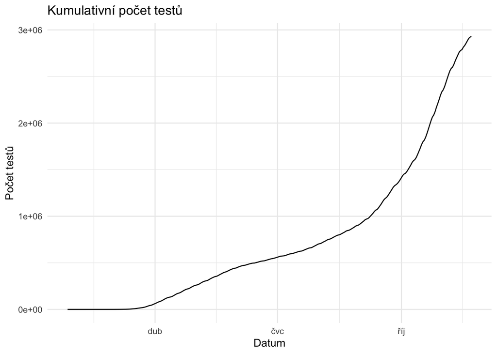

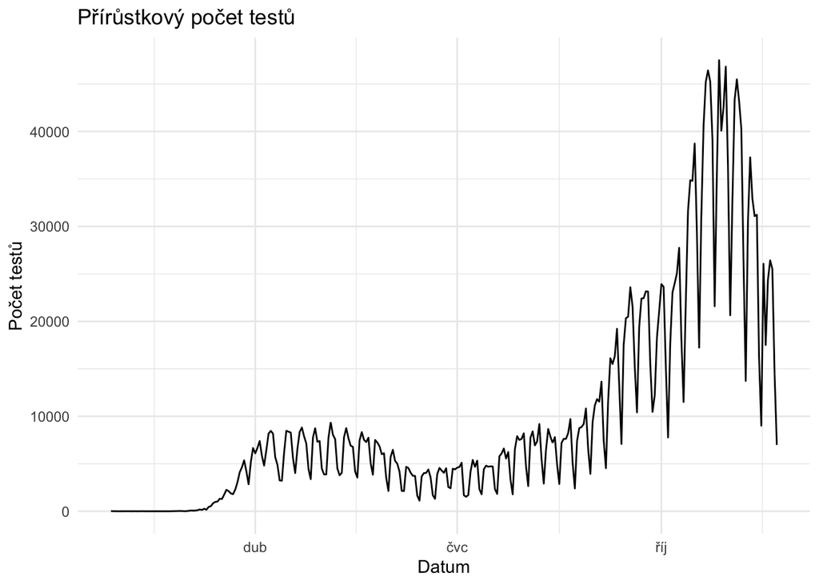

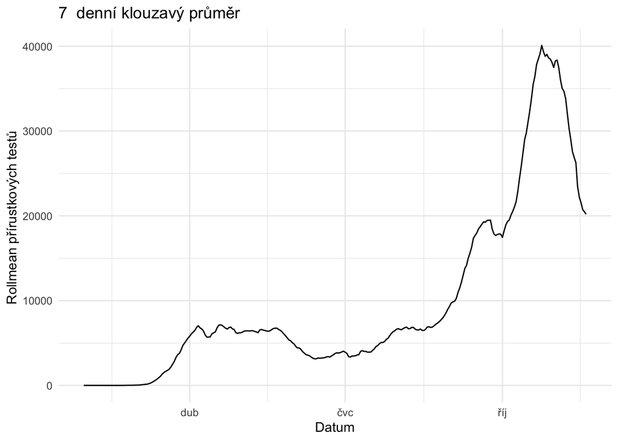

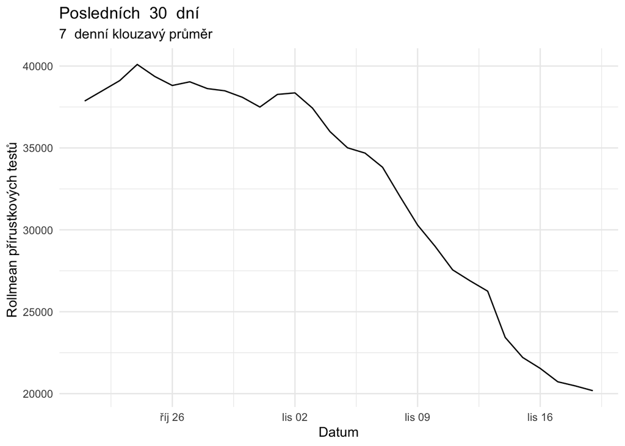

## Pozitivní případy

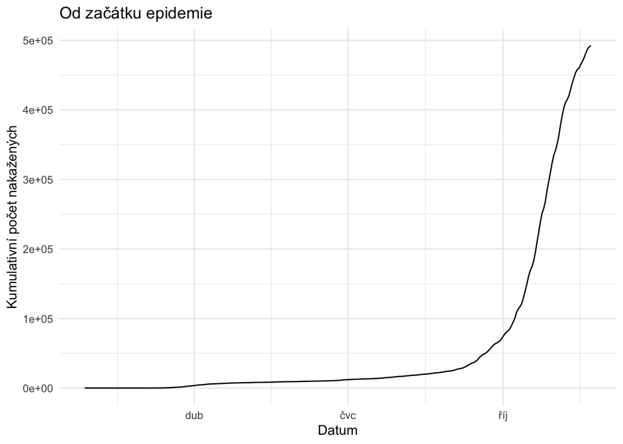

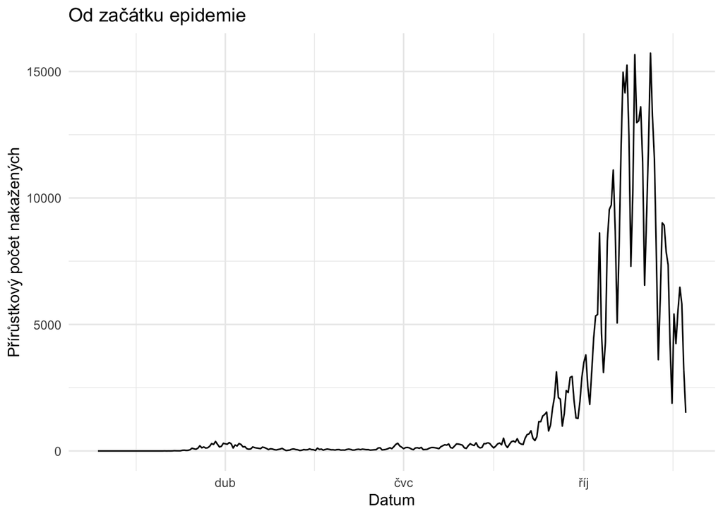

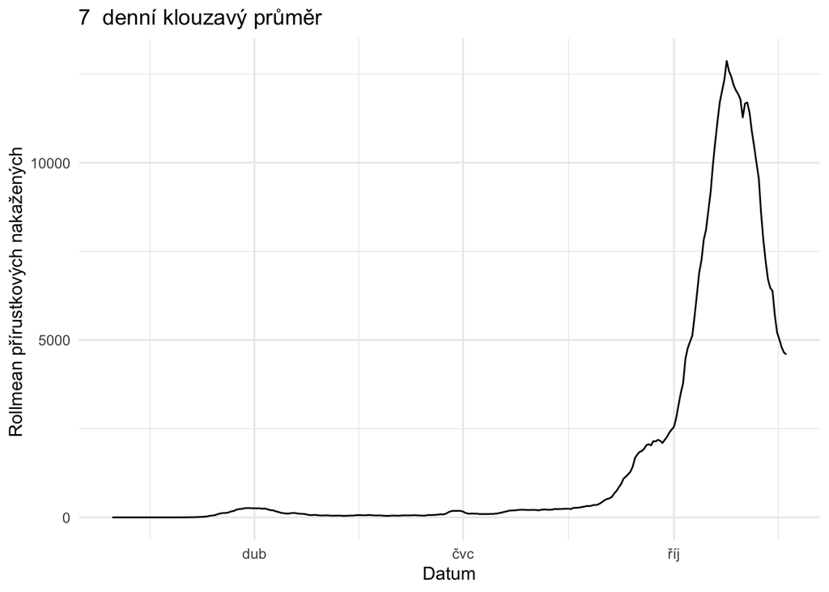

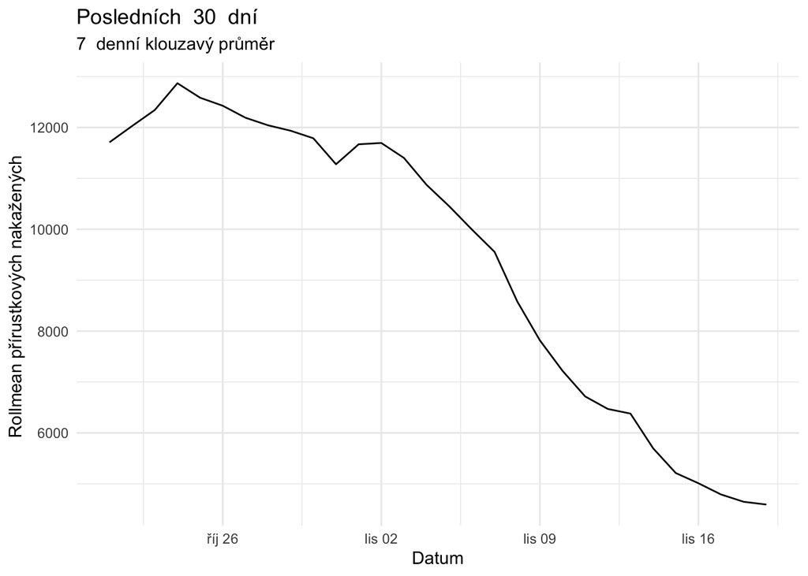

## Podíl pozitivních testů

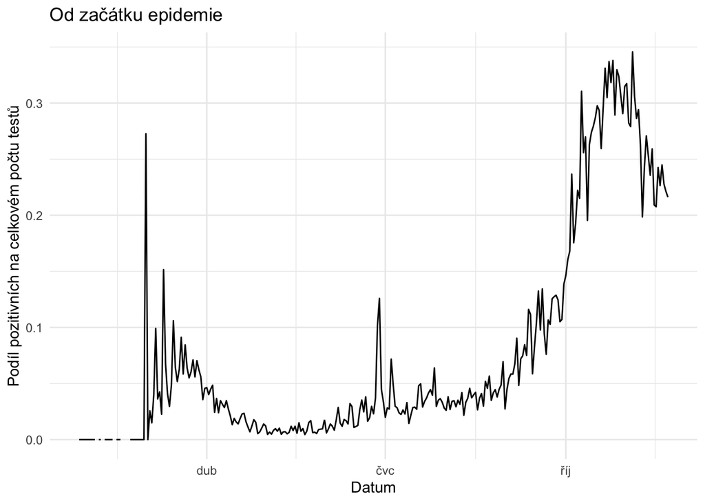

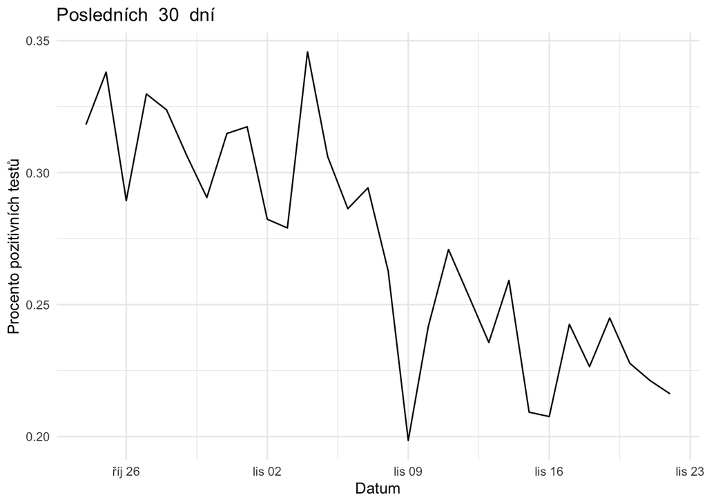

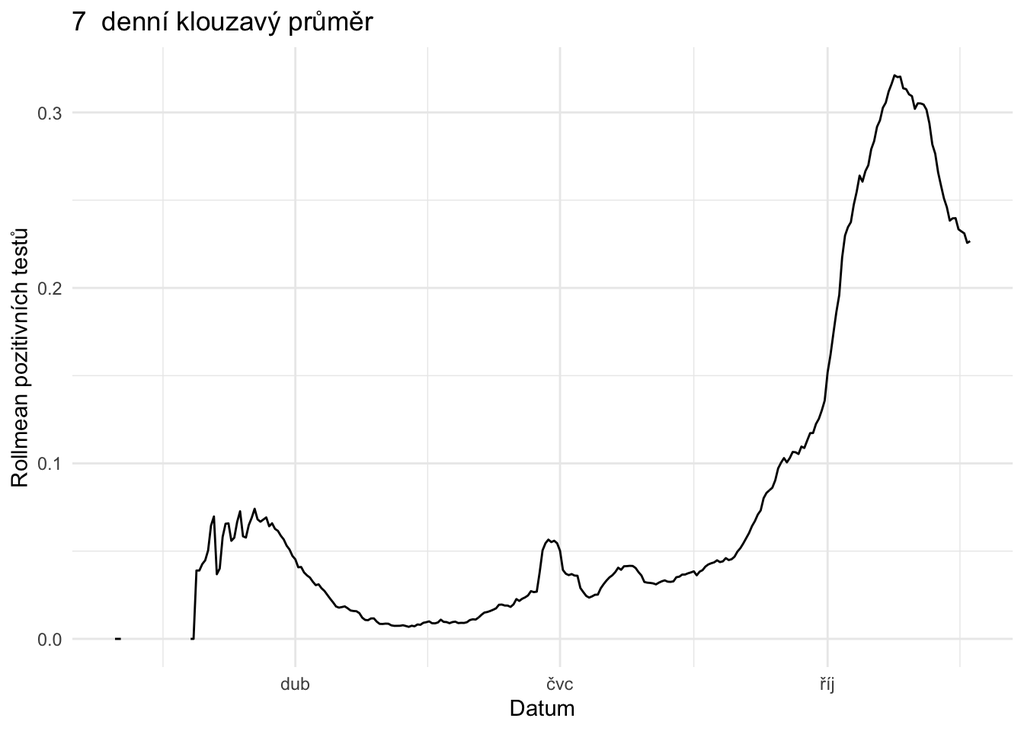

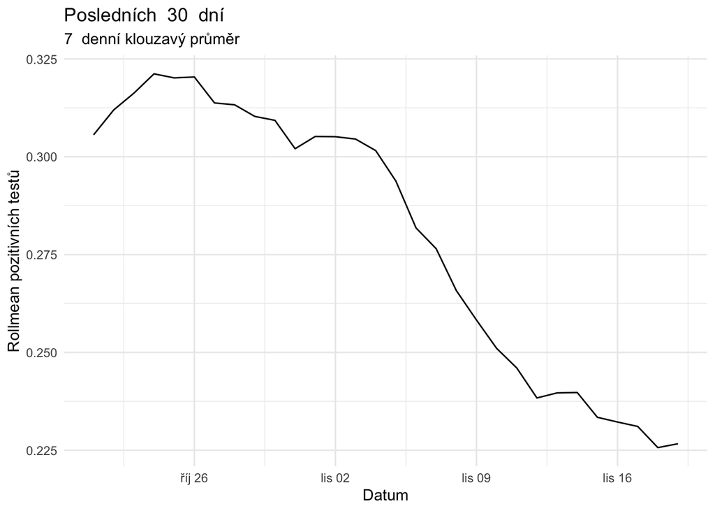

Podíl pozitivních testů na celkovém počtu od začátku epidemie je `16.801` %.

Podíl pozitivních testů na celkovém počtu za posledních 30 dní je `28.067` %.

# Modely

## Linearní model

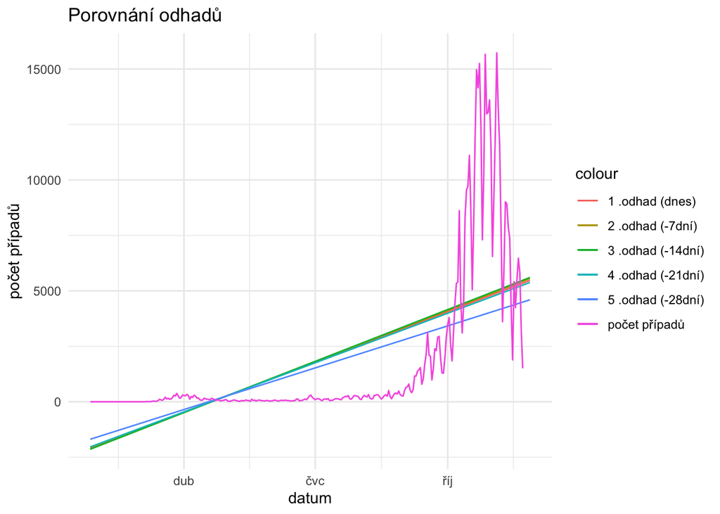

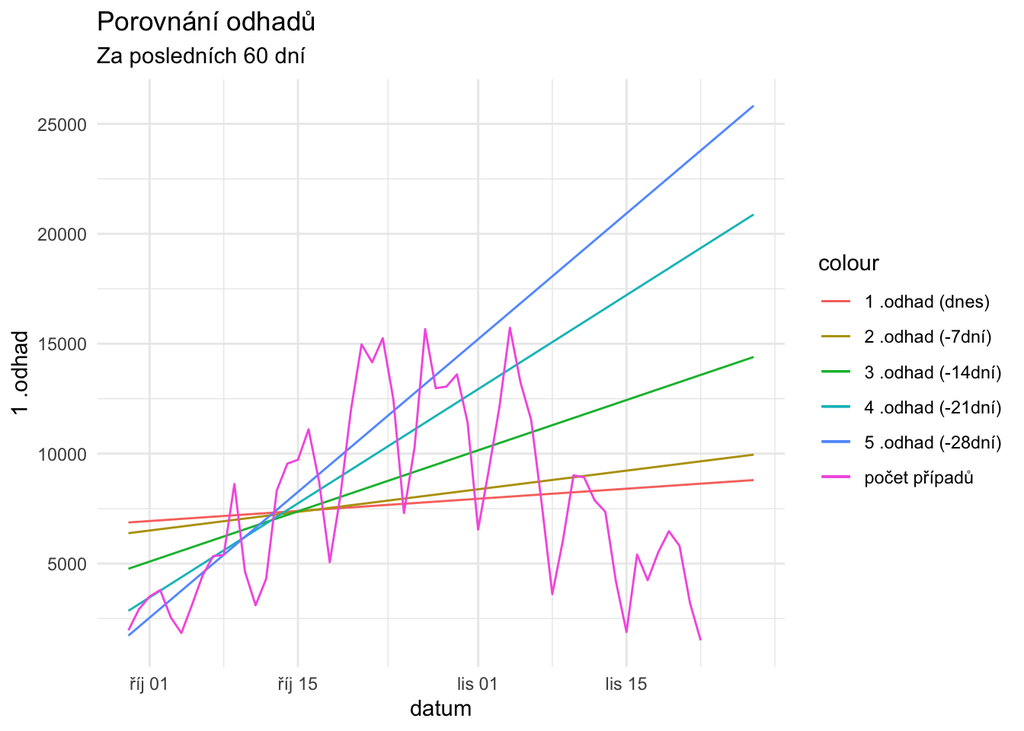

### Data (Lineární model)

#### Od začátku epidemie

Podle lineárního modelu bychom tímto tempem měli dne `2020-11-27` podle

- 1. odhadu `5469` nakažených denně
- 2. odhadu `5552` nakažených denně
- 3. odhadu `5605` nakažených denně
- 4. odhadu `5377` nakažených denně
- 5. odhadu `4595` nakažených denně

#### Za posledních `60` dní

Podle lineárního modelu bychom tímto tempem měli dne `2020-11-27` podle

- 1. odhadu `8798` nakažených denně
- 2. odhadu `9954` nakažených denně
- 3. odhadu `14398` nakažených denně
- 4. odhadu `20879` nakažených denně
- 5. odhadu `25830` nakažených denně

## Kvadratický model

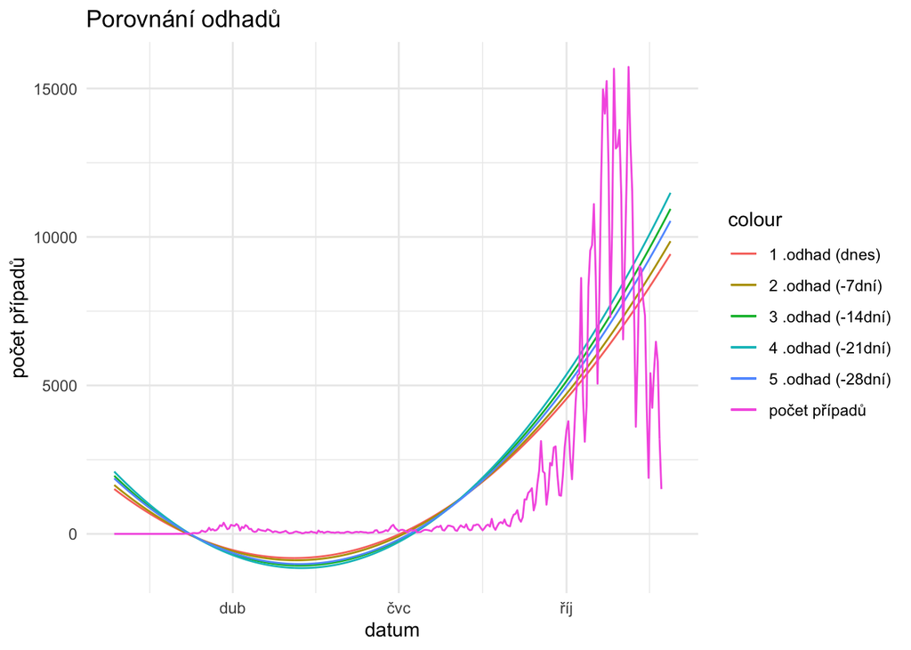

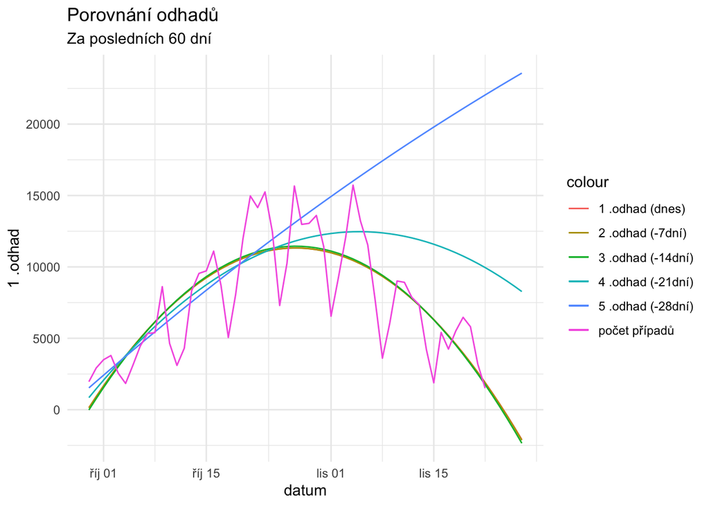

### Data (Kvadratický model)

#### Od začátku epidemie

Podle kvadratického modelu bychom tímto tempem měli dne `2020-11-27` podle

- 1. odhadu `9422` nakažených denně
- 2. odhadu `9857` nakažených denně
- 3. odhadu `10944` nakažených denně
- 4. odhadu `11486` nakažených denně
- 5. odhadu `10539` nakažených denně

#### Za posledních `60` dní

- 1. odhadu `-2094` nakažených denně
- 2. odhadu `-2133` nakažených denně
- 3. odhadu `-2347` nakažených denně
- 4. odhadu `8275` nakažených denně
- 5. odhadu `23571` nakažených denně

## Exponential model

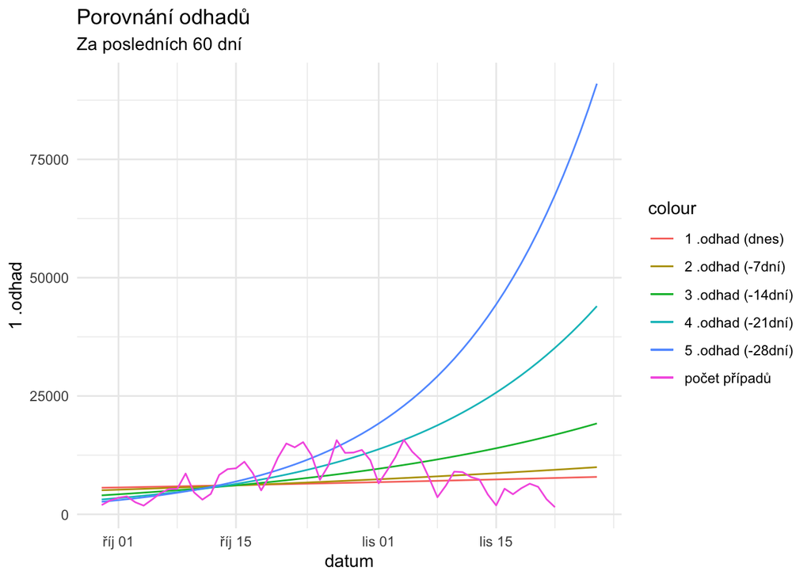

### Data (Exponential model)

#### Za posledních `60` dní

Podle exponencionálního modelu bychom tímto tempem měli dne `2020-11-27` podle

- 1. odhadu `7904` nakažených denně
- 2. odhadu `9958` nakažených denně
- 3. odhadu `19198` nakažených denně
- 4. odhadu `43983` nakažených denně
- 5. odhadu `90989` nakažených denně

Podle exponencionálního modelu bychom tímto tempem měli dnes dne `2020-11-23` podle

- 1. odhadu `7723` nakažených denně
- 2. odhadu `9515` nakažených denně
- 3. odhadu `17265` nakažených denně
- 4. odhadu `36779` nakažených denně
- 5. odhadu `71608` nakažených denně

# Informace

Update proběhl `2020-11-24 00:10:57`.

Poslední data jsou z `2020-11-22` ze stránek ministerstva zdravotnictví ČR (https://onemocneni-aktualne.mzcr.cz/covid-19)